# Moorea Exercise

Owen Liu

Monday, October 12, 2015

This is an exploratory document to both:

- explore some of the public Moorea datasets [available online](http://mcr.lternet.edu/data/), and to
- practice using RMarkdown and GitHub

## Data Organization and Sub-setting

The first dataset is a .csv of Annual Visual Fish Surveys from Moorea since 2006, with 56918 observations in 24 variables

```r
vfs <- read.csv('~/github/moorea_exploration/data/MCR_LTER_Annual_Fish_Survey_20150318.csv')
names(vfs)
```

```
##  [1] "Year"           "Date"           "Start"          "End"
##  [5] "Location"       "Site"           "Habitat"        "Transect"
##  [9] "Swath"          "Taxonomy"       "Family"         "Count"
## [13] "Total_Length"   "Length_Anomaly" "Biomass"        "Coarse_Trophic"
## [17] "Fine_Trophic"   "Cloud_Cover"    "Wind_Velocity"  "Sea_State"
## [21] "Swell"          "Visibility"     "Surge"          "Diver"
```

The transects have data like date, location, and habitat type of the dive site, along with the taxonomy of the species identified and their lengths, abundance, etc.

Let’s summarize some of these data and see what they look like (mostly from the doBy pkg). Data from all years pooled at first.

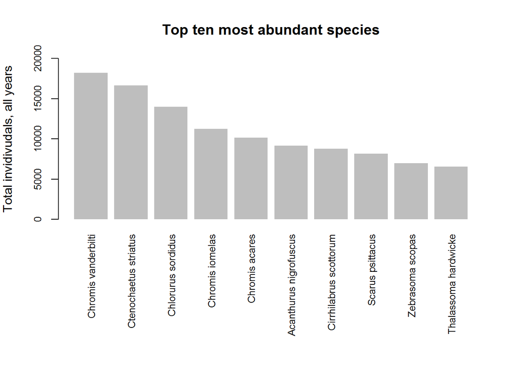

```r
## The summaryBy() function summarizes data according to a specified function
## and by the subset of variables you specify
## We could make a list of the most abundant species by all individuals for all years
abun <- summaryBy(Count~Taxonomy, data= vfs, FUN=sum, na.rm=TRUE) #summarizes the data
abun <- abun[order(-abun[,2]),] #sorts by total abundance
top_10 <- abun[1:10,] #top 10 most abundant species
top_10.names <- as.vector(top_10[,'Taxonomy']) #names (for later use)
par(mar=c(10,4,4,2))
barplot(top_10[,2],names.arg=top_10[,1],las=3, ylim=c(0,20000),
        border=NA, ylab='Total invidivudals, all years',cex.names=0.8,
        main='Top ten most abundant species',cex.axis=0.8)
```

## Calculating mean size by habitat

I want to look at which species may have ontogenetic habitat shifts between fringing reef, backreef, and forereef. One way to start to investigate this is to calculate average size for each species in each habitat, and then see if there are significant differences between habitats.

We’re looking for something like this:

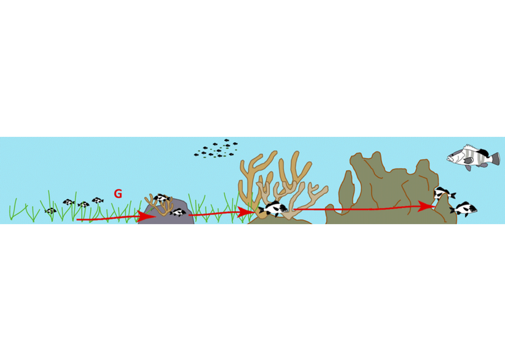

First, let’s look at all the species that have at least 10 observed individuals in each habitat in the data (since, presumably, some species don’t utilize all habitats). In other words, let’s limit our later analysis by those species that are represented in each habitat.

```r
## Original dataset, counts aggregated by species, habitat, and length bin
sp_hab <- summaryBy(Count~Taxonomy + Habitat + Total_Length, data=vfs, FUN=sum,na.rm=TRUE)

knitr::kable(head(sp_hab,8))
```

```
##
##
## |Taxonomy                  |Habitat | Total_Length| Count.sum|
## |:-------------------------|:-------|------------:|---------:|
## |                          |        |           NA|         0|
## |Abudefduf septemfasciatus |BA      |           80|         1|
## |Abudefduf septemfasciatus |BA      |           90|         1|
## |Abudefduf septemfasciatus |BA      |          100|         9|
## |Abudefduf septemfasciatus |BA      |          110|        12|
## |Abudefduf septemfasciatus |BA      |          115|         1|
## |Abudefduf septemfasciatus |BA      |          120|         5|
## |Abudefduf septemfasciatus |BA      |          125|         3|
```

```r
## Function returns 1 if species is represented by at least 10 individuals in each habitat
## and returns 0 if not
rep_hab <- function(species) {
  dat<-subset(sp_hab,sp_hab$Taxonomy==species) # all data for the species
  fr <- subset(dat,dat$Habitat=='FR') # fringing reef
  br <- subset(dat,dat$Habitat=='BA') # back reef
  fo <- subset(dat,dat$Habitat=='FO') # forereef
  if(sum(fr$Count.sum)>9 & sum(br$Count.sum)>9 & sum(fo$Count.sum)>9) return(1)
  else return(0)
}
```

Now we can limit our full dataset to just the species that are represented in all habitats

```r
rep_check <- sapply(sp_hab$Taxonomy,rep_hab) #check for representation
sp_rep <- sp_hab[rep_check==1,] #keep all the rows for represented species
sp_rep.names <- as.vector(unique(sp_rep$Taxonomy))

length(unique(sp_rep$Taxonomy)) #How many species?
```

```
## [1] 69
```

We can see that there are 69 species that fit the representation criteria. Now let’s calculate the mean lengths for each species in each of the three habitats.

```r
## Function for mean length by habitat

species.mean<-function(data,species,habitat) {
  sp.data <- subset(data,data$Taxonomy==species & data$Habitat==habitat)
  hab.count <- sum(sp.data$Count.sum)
  freq <- sp.data$Count.sum/hab.count # relative frequency of a size class
  hab.mean <- sum(sp.data$Total_Length*freq) # mean is the sum of all length classes times their relative frequencies
  return(cbind(hab.count,hab.mean))
}

names <- as.vector(sapply(sp_rep.names,function(x) rep(x,3),USE.NAMES=F)) #expands names list so each species has 3 habitats

hab.vec <- rep(c('FR','BA','FO'),length(sp_rep.names))

## Data frame of species and their mean size by habitat
mean.lengths <- mapply(species.mean,species=names,habitat=hab.vec,MoreArgs=list(data=sp_rep))
hab.means <- data.frame(names,hab.vec,mean.lengths[1,],mean.lengths[2,])

names(hab.means)<-c('Species','Habitat','Total_Count','Mean_Length')

#DT::datatable(hab.means,caption='Species Mean Length By Habitat')
```

To run an ANOVA, we have to ‘expand’ the data such that each individual count is recorded as a separate observation. Here’s a quick function to do that.

```r
exp.counts<- function(data,species,habitat) {
  x <- subset(data,data$Taxonomy==species & data$Habitat==habitat)
  # next line replicates the total length based on how many individuals were counted in that length class
  x2 <- unlist(mapply(function(x,y) rep(x,y), x$Total_Length,x$Count.sum))
  x2<- as.numeric(x2) #has to be a continuous vector for later ANOVA
  x3 <- data.frame(length=x2,habitat=rep(habitat,length(x2)))
  return(x3) #returns the data as a column of lengths and a column of habitats, so now one
  # row is one 'observation' of length
}
```

Let’s try to look at one species after ‘expanding’ the data in this way. Randomly, I’ll use the species *Acanthurus nigricans*, the [whitecheek surgeonfish](http://www.discoverlife.org/IM/I_RR/0019/320/Acanthurus_nigricans,I_RR1947.jpg).

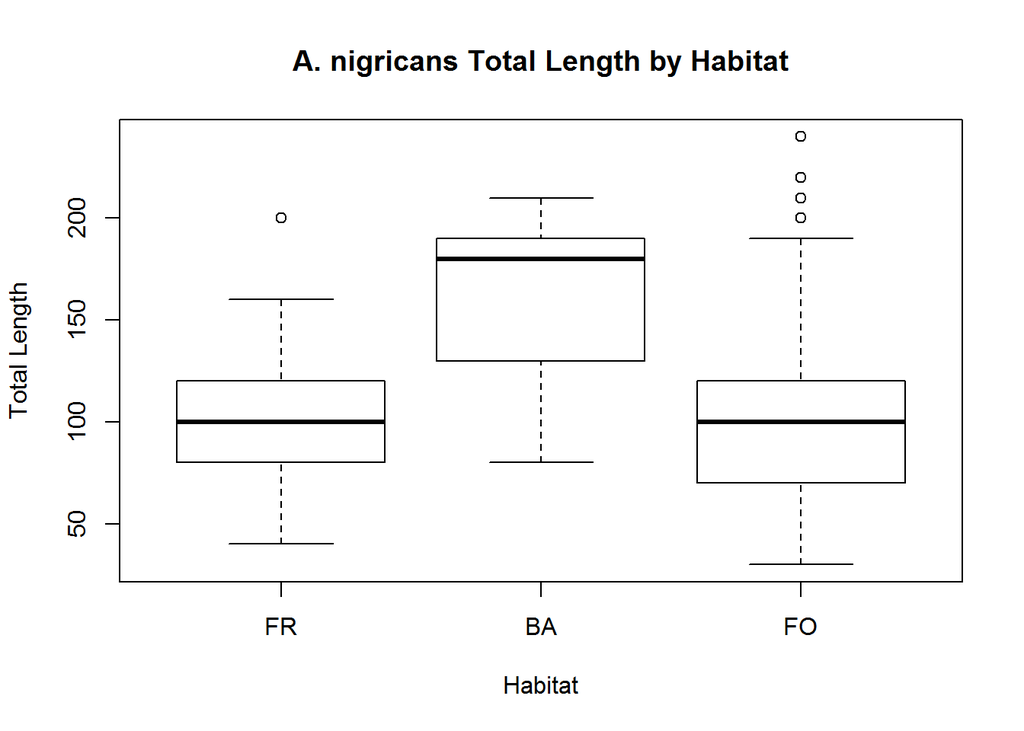

```r
a_nigricans.fr <- exp.counts(sp_rep,'Acanthurus nigricans','FR') #fringing reef data expansion
a_nigricans.br <- exp.counts(sp_rep,'Acanthurus nigricans','BA') #back reef data expansion
a_nigricans.fo <- exp.counts(sp_rep,'Acanthurus nigricans','FO') #forereef data expansion

a_nigricans.all <- rbind(a_nigricans.fr, a_nigricans.br, a_nigricans.fo) #combined
boxplot(length~habitat,data=a_nigricans.all, xlab='Habitat',ylab='Total Length',
        main= 'A. nigricans Total Length by Habitat')
```

Now we can do an ANOVA to test for significant difference between the three habitats

```r
an.aov<-aov(length~habitat,data=a_nigricans.all) #the simple ANOVA for a. nigricans
summary(an.aov)
```

```
##              Df  Sum Sq Mean Sq F value Pr(>F)
## habitat       2  414886  207443     162 <2e-16 ***
## Residuals   960 1230430    1282
## ---
## Signif. codes:  0 '***' 0.001 '**' 0.01 '*' 0.05 '.' 0.1 ' ' 1
```

We can see that for this species there is a significant (p<<0.05) difference between mean lengths by habitat! We can also look closer at pairwise comparisons by using Tukey’s Honest Significant Differences method

```
##          diff    lwr     upr     p adj
## BA-FR  61.820  45.77  77.867 3.300e-13
## FO-FR  -4.637 -18.76   9.487 7.211e-01
## FO-BA -66.458 -75.13 -57.784 3.019e-13
```

For all represented species…

```r
dat.all <- list() #List of data, one for each species
aov.all <- list() #List of ANOVAs, one for each species
tukey.all <- list() #List of Tukey tests, one for each species

for (i in 1:length(sp_rep.names)) {
  sp <- sp_rep.names[i] #species name
  fr.dat <- exp.counts(sp_rep,sp,'FR') #fringing reef data expansion
  br.dat <- exp.counts(sp_rep,sp,'BA') #back reef data expansion
  fo.dat <- exp.counts(sp_rep,sp,'FO') #forereef data expansion

  dat.sp <- rbind(fr.dat,br.dat,fo.dat) #combined
  dat.all[[sp]] <- dat.sp #add species to the list(s)
}

aov.all <- lapply(dat.all, function(x) aov(length~habitat,data=x)) #run an ANOVA

tukey.all <- lapply(aov.all,TukeyHSD) #run a Tukey test
```

Having the data in this way allows us to look up data, ANOVAs, and the Tukey tests by species name, e.g.

```r
tukey.all[['Zebrasoma scopas']]
```

```
##   Tukey multiple comparisons of means
##     95% family-wise confidence level
##
## Fit: aov(formula = length ~ habitat, data = x)
##
## $habitat
##         diff    lwr    upr  p adj
## BA-FR 26.937 24.008 29.867 0.0000
## FO-FR 22.172 19.916 24.428 0.0000
## FO-BA -4.766 -7.929 -1.602 0.0012
```

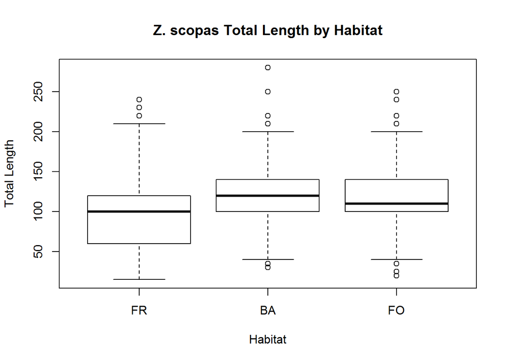

```r
boxplot(length~habitat,data=dat.all[['Zebrasoma scopas']], xlab='Habitat',ylab='Total Length',
        main= 'Z. scopas Total Length by Habitat')
```

Now we can look for only those species that have significant differences between habitats, first using our ANOVA results

```r
## a function that takes an ANOVA and tests for significance based on p-value
## returns 1 if significant, zero if not
aov.sig.check <- function (anova) {

  p <- summary(anova)[[1]][['Pr(>F)']][1] #this is how to access the p-value alone

  if(p<0.05) return(1)
  else return(0)
}

#now apply it to our list of ANOVAs
sig_aovs <- sapply(aov.all, aov.sig.check) #returns a vector
names_sig_aovs <- names(subset(sig_aovs,sig_aovs==1)) #significant species
names_sig_aovs
```

```
##  [1] "Abudefduf sexfasciatus"     "Acanthurus nigricans"
##  [3] "Acanthurus nigricauda"      "Acanthurus nigrofuscus"
##  [5] "Acanthurus pyroferus"       "Acanthurus triostegus"
##  [7] "Balistapus undulatus"       "Canthigaster solandri"
##  [9] "Centropyge flavissima"      "Cephalopholis argus"
## [11] "Chaetodon lunulatus"        "Chaetodon ornatissimus"
## [13] "Chaetodon reticulatus"      "Chaetodon ulietensis"
## [15] "Chaetodon unimaculatus"     "Cheilinus chlorourus"
## [17] "Cheilinus trilobatus"       "Chlorurus microrhinos"
## [19] "Chlorurus sordidus"         "Chromis iomelas"
## [21] "Chromis margaritifer"       "Cirrhilabrus scottorum"
## [23] "Coris aygula"               "Ctenochaetus binotatus"
## [25] "Ctenochaetus striatus"      "Dascyllus flavicaudus"
## [27] "Dascyllus trimaculatus"     "Epibulus insidiator"
## [29] "Gnathodentex aureolineatus" "Gomphosus varius"
## [31] "Halichoeres marginatus"     "Heniochus chrysostomus"
## [33] "Labroides bicolor"          "Labroides dimidiatus"
## [35] "Melichthys vidua"           "Monotaxis grandoculis"
## [37] "Naso lituratus"             "Parapercis millepunctata"
## [39] "Parupeneus cyclostomus"     "Parupeneus insularis"
## [41] "Parupeneus multifasciatus"  "Pseudanthias olivaceus"
## [43] "Pseudocheilinus hexataenia" "Scarus frenatus"
## [45] "Scarus niger"               "Scarus oviceps"
## [47] "Scarus psittacus"           "Scarus schlegeli"
## [49] "Siganus argenteus"          "Stegastes fasciolatus"
## [51] "Stethojulis bandanensis"    "Thalassoma amblycephalum"
## [53] "Thalassoma hardwicke"       "Thalassoma lutescens"
## [55] "Valenciennea strigata"      "Zebrasoma scopas"
## [57] "Zebrasoma veliferum"
```